# Task3

2022-11-11

## Предварительный анализ данных.

Прочитаем и обработаем данные. Среди данных не может быть отрицательных значений, NA обозначаются как -999.

```r
library(readxl)
library(dplyr)
library(tidyr)
```

```r
df <- read_excel("Sleep/SLEEP_shortname.xls")
df[df < 0] <- NA

head(df)
```

```
## # A tibble: 6 × 11
##   NAME     BODY_…¹ BRAIN…² SLOWW…³ PARADOX SLEEP LIFES…⁴ GESTT…⁵ PRED_…⁶ EXP_IND
##   <chr>      <dbl>   <dbl>   <dbl>   <dbl> <dbl>   <dbl>   <dbl>   <dbl>   <dbl>
## 1 African… 6654     5712      NA      NA     3.3    38.6     645       3       5
## 2 African…    1        6.6     6.3     2     8.3     4.5      42       3       1
## 3 Arctic …    3.38    44.5    NA      NA    12.5    14        60       1       1
## 4 Arc. gr…    0.92     5.7    NA      NA    16.5    NA        25       5       2
## 5 Asian e… 2547     4603       2.1     1.8   3.9    69       624       3       5
## 6 Baboon     10.6    180.      9.1     0.7   9.8    27       180       4       4
## # … with 1 more variable: DANG_IND <dbl>, and abbreviated variable names
## #   ¹BODY_WEI, ²BRAIN_WE, ³SLOWWAVE, ⁴LIFESPAN, ⁵GESTTIME, ⁶PRED_IND
## # ℹ Use `colnames()` to see all variable names
```

```r
length(df$NAME)
```

```
## [1] 62
```

Кроме индексов-факторов, все признаки количественные. Индексы - порядковые признаки.

Посмотрим на данные.

```r
library(ggplot2)
library(GGally)
```

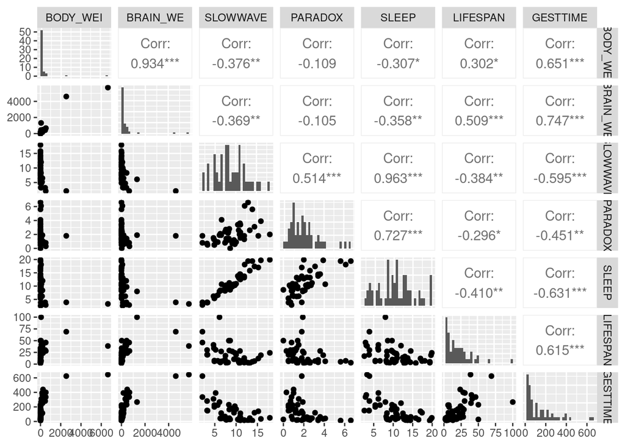

```r
df %>% dplyr::select(-NAME) %>%
  ggpairs(diag=list(continuous = "barDiag"),
          columns = c("BODY_WEI", "BRAIN_WE", "SLOWWAVE", "PARADOX", "SLEEP", "LIFESPAN", "GESTTIME"))
```

Преобразуем данные. Переведем вес животного в граммы, продолжительность жизни в дни. Логарифмируем данные, чтобы было легче наблюдать корреляции (выше заметны сильно отличающиеся индивиды, это слоны). Факторизуем индексы.

```r
dfNew <- df %>% mutate(PRED_IND = as.factor(PRED_IND), EXP_IND = as.factor(EXP_IND),
                   DANG_IND = as.factor(DANG_IND),
                   BODY_WEI = log(BODY_WEI * 1000), BRAIN_WE = log(BRAIN_WE),
                   LIFESPAN = log(LIFESPAN * 365.25), GESTTIME = log(GESTTIME))
```

Посмотрим на новые данные. Сгруппируем индивидов по факторам.

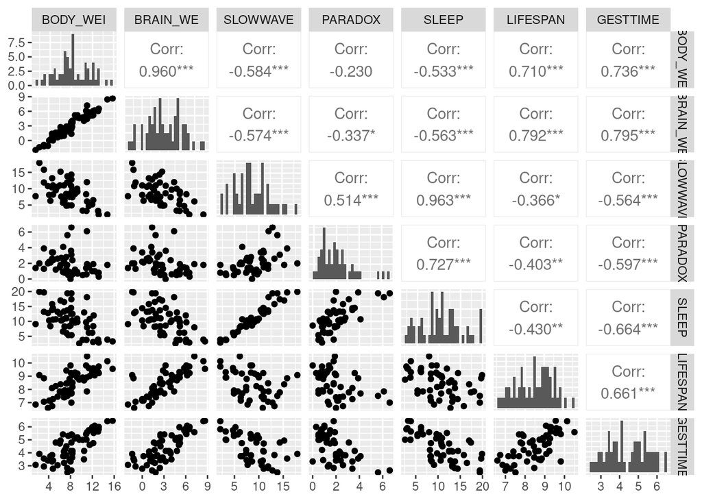

```r
dfNew %>% dplyr::select(-NAME) %>%
  ggpairs(diag=list(continuous = "barDiag"),
          columns = c("BODY_WEI", "BRAIN_WE", "SLOWWAVE", "PARADOX", "SLEEP", "LIFESPAN", "GESTTIME"))
```

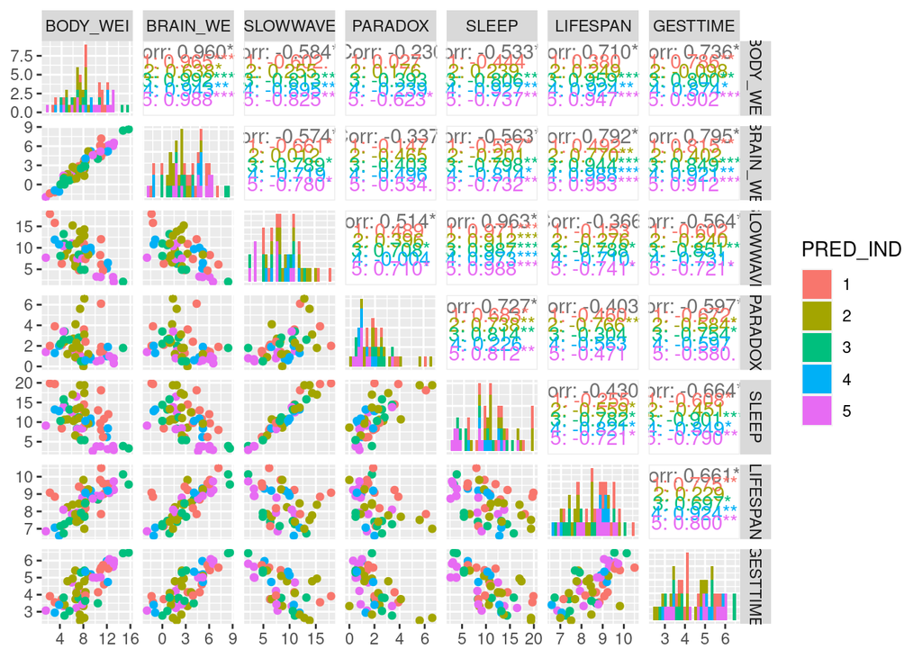

```r
dfNew %>% dplyr::select(-NAME) %>%
  ggpairs(diag=list(continuous = "barDiag"), aes(colour=PRED_IND), legend=1,
          columns=c("BODY_WEI", "BRAIN_WE", "SLOWWAVE", "PARADOX", "SLEEP", "LIFESPAN", "GESTTIME"))
```

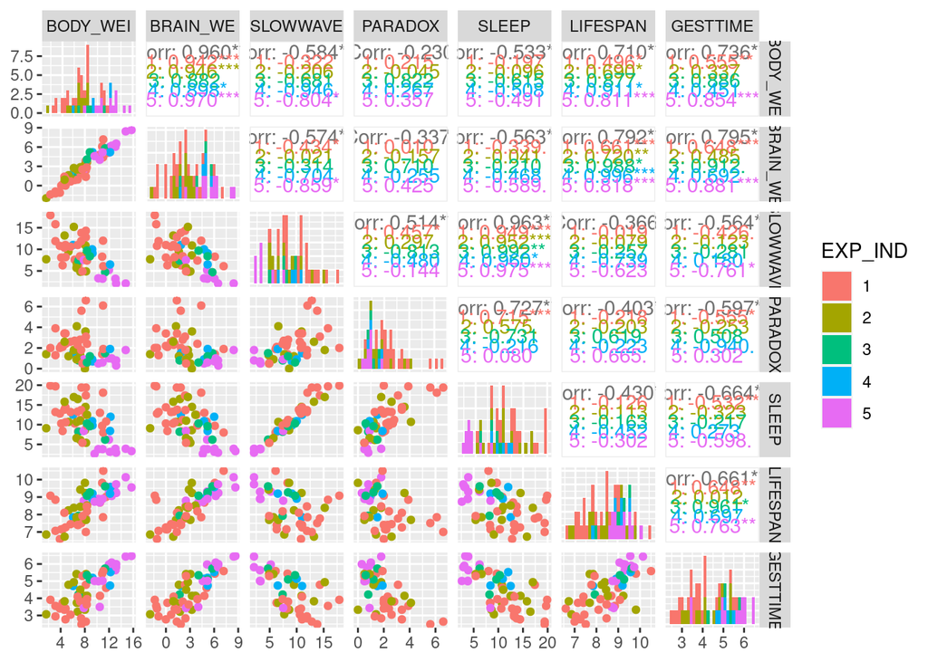

```r
dfNew %>% dplyr::select(-NAME) %>%
  ggpairs(diag=list(continuous = "barDiag"), aes(colour=EXP_IND), legend=1,
          columns=c("BODY_WEI", "BRAIN_WE", "SLOWWAVE", "PARADOX", "SLEEP", "LIFESPAN", "GESTTIME"))
```

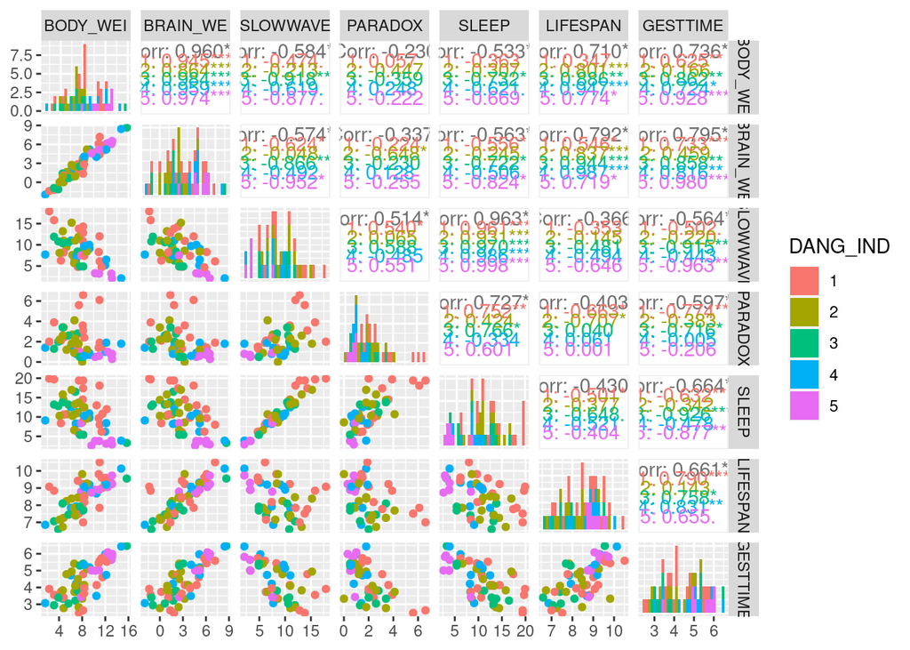

```r
dfNew %>% dplyr::select(-NAME) %>%
  ggpairs(diag=list(continuous = "barDiag"), aes(colour=DANG_IND), legend=1,
          columns=c("BODY_WEI", "BRAIN_WE", "SLOWWAVE", "PARADOX", "SLEEP", "LIFESPAN", "GESTTIME"))
```

Используем описательные статистики для распределений признаков в изначальной и новой выборках.

```r
library(moments)
library(entropy)
```

Вес тела.

```r
cat("df:\n")
```

```
## df:
```

```r
mean(df$BODY_WEI, na.rm = TRUE)
```

```
## [1] 198.79
```

```r
quantile(df$BODY_WEI, probs = c(0, 0.25, 0.5, 0.75, 1), na.rm = TRUE)
```

```
##        0%       25%       50%       75%      100%
##    0.0050    0.6000    3.3425   48.2025 6654.0000
```

```r
var(df$BODY_WEI, na.rm = TRUE)
```

```
## [1] 808485.1
```

```r
skewness(df$BODY_WEI, na.rm = TRUE)
```

```
## [1] 6.403732
```

```r
cat("\ndfNew:\n")
```

```
##
## dfNew:
```

```r
mean(dfNew$BODY_WEI, na.rm = TRUE)
```

```
## [1] 8.245294
```

```r
quantile(dfNew$BODY_WEI, probs = c(0, 0.25, 0.5, 0.75, 1), na.rm = TRUE)
```

```
##        0%       25%       50%       75%      100%
##  1.609438  6.387457  8.114393 10.771653 15.710729
```

```r
var(dfNew$BODY_WEI, na.rm = TRUE)
```

```
## [1] 9.753926
```

```r
skewness(dfNew$BODY_WEI, na.rm = TRUE)
```

```
## [1] 0.1489489
```

```r
kurtosis(dfNew$BODY_WEI, na.rm = TRUE)
```

```
## [1] 2.558601
```

Вес мозга.

```r
cat("df:\n")
```

```
## df:
```

```r
mean(df$BRAIN_WE, na.rm = TRUE)
```

```
## [1] 283.1342
```

```r
quantile(df$BRAIN_WE, probs = c(0, 0.25, 0.5, 0.75, 1), na.rm = TRUE)
```

```
##      0%     25%     50%     75%    100%
##    0.14    4.25   17.25  166.00 5712.00
```

```r
var(df$BRAIN_WE, na.rm = TRUE)
```

```
## [1] 865418.9
```

```r
skewness(df$BRAIN_WE, na.rm = TRUE)
```

```
## [1] 4.948056
```

```r
cat("\ndfNew:\n")
```

```
##
## dfNew:
```

```r
mean(dfNew$BRAIN_WE, na.rm = TRUE)
```

```
## [1] 3.140198
```

```r
quantile(dfNew$BRAIN_WE, probs = c(0, 0.25, 0.5, 0.75, 1), na.rm = TRUE)
```

```
##        0%       25%       50%       75%      100%
## -1.966113  1.442080  2.847707  5.111485  8.650325
```

```r
var(dfNew$BRAIN_WE, na.rm = TRUE)
```

```
## [1] 5.985421
```

```r
skewness(dfNew$BRAIN_WE, na.rm = TRUE)
```

```
## [1] 0.04451474
```

```r
kurtosis(dfNew$BRAIN_WE, na.rm = TRUE)
```

```
## [1] 2.460244
```

Медленный сон.

```r
cat("df:\n")
```

```
## df:
```

```r
mean(df$SLOWWAVE, na.rm = TRUE)
```

```
## [1] 8.672917
```

```r
quantile(df$SLOWWAVE, probs = c(0, 0.25, 0.5, 0.75, 1), na.rm = TRUE)
```

```
##    0%   25%   50%   75%  100%
##  2.10  6.25  8.35 11.00 17.90
```

```r
var(df$SLOWWAVE, na.rm = TRUE)
```

```
## [1] 13.44287
```

```r
skewness(df$SLOWWAVE, na.rm = TRUE)
```

```
## [1] 0.2888462
```

```r
kurtosis(dfNew$SLOWWAVE, na.rm = TRUE)
```

```
## [1] 2.665648
```

Быстрый сон.

```r
cat("df:\n")
```

```
## df:
```

```r
mean(df$PARADOX, na.rm = TRUE)
```

```
## [1] 1.972
```

```r
quantile(df$PARADOX, probs = c(0, 0.25, 0.5, 0.75, 1), na.rm = TRUE)
```

```
##   0%  25%  50%  75% 100%
## 0.00 0.90 1.80 2.55 6.60
```

```r
var(df$PARADOX, na.rm = TRUE)
```

```
## [1] 2.081241
```

```r
skewness(df$PARADOX, na.rm = TRUE)
```

```
## [1] 1.408774
```

```r
kurtosis(dfNew$PARADOX, na.rm = TRUE)
```

```
## [1] 4.976392
```

Cон.

```r
cat("df:\n")
```

```
## df:
```

```r
mean(df$SLEEP, na.rm = TRUE)
```

```
## [1] 10.53276
```

```r
quantile(df$SLEEP, probs = c(0, 0.25, 0.5, 0.75, 1), na.rm = TRUE)
```

```
##    0%   25%   50%   75%  100%
##  2.60  8.05 10.45 13.20 19.90
```

```r
var(df$SLEEP, na.rm = TRUE)
```

```
## [1] 21.22224
```

```r
skewness(df$SLEEP, na.rm = TRUE)
```

```
## [1] 0.1960028
```

```r
kurtosis(dfNew$SLEEP, na.rm = TRUE)
```

```
## [1] 2.43348
```

Продолжительность жизни.

```r
cat("df:\n")
```

```
## df:
```

```r
mean(df$LIFESPAN, na.rm = TRUE)
```

```
## [1] 19.87759
```

```r
quantile(df$LIFESPAN, probs = c(0, 0.25, 0.5, 0.75, 1), na.rm = TRUE)
```

```
##      0%     25%     50%     75%    100%
##   2.000   6.625  15.100  27.750 100.000
```

```r
var(df$LIFESPAN, na.rm = TRUE)
```

```
## [1] 331.4677
```

```r
skewness(df$LIFESPAN, na.rm = TRUE)
```

```
## [1] 1.961301
```

```r
cat("\ndfNew:\n")
```

```
##
## dfNew:
```

```r
mean(dfNew$LIFESPAN, na.rm = TRUE)
```

```
## [1] 8.493641
```

```r
quantile(dfNew$LIFESPAN, probs = c(0, 0.25, 0.5, 0.75, 1), na.rm = TRUE)
```

```
##        0%       25%       50%       75%      100%
##  6.593729  7.790911  8.612616  9.223695 10.505752
```

```r
var(dfNew$LIFESPAN, na.rm = TRUE)
```

```
## [1] 0.8902197
```

```r
skewness(dfNew$LIFESPAN, na.rm = TRUE)
```

```
## [1] -0.1672212
```

```r
kurtosis(dfNew$LIFESPAN, na.rm = TRUE)
```

```
## [1] 2.158602
```

Продолжительность периода вынашивания потомства.

```r
cat("df:\n")
```

```
## df:
```

```r
mean(df$GESTTIME, na.rm = TRUE)
```

```
## [1] 142.3534
```

```r
quantile(df$GESTTIME, probs = c(0, 0.25, 0.5, 0.75, 1), na.rm = TRUE)
```

```
##     0%    25%    50%    75%   100%
##  12.00  35.75  79.00 207.50 645.00
```

```r
var(df$GESTTIME, na.rm = TRUE)
```

```
## [1] 21551.72
```

```r
skewness(df$GESTTIME, na.rm = TRUE)
```

```
## [1] 1.639645
```

```r
cat("\ndfNew:\n")
```

```
##
## dfNew:
```

```r
mean(dfNew$GESTTIME, na.rm = TRUE)
```

```
## [1] 4.444191
```

```r
quantile(dfNew$GESTTIME, probs = c(0, 0.25, 0.5, 0.75, 1), na.rm = TRUE)
```

```
##       0%      25%      50%      75%     100%
## 2.484907 3.575908 4.359659 5.334910 6.469250
```

```r
var(dfNew$GESTTIME, na.rm = TRUE)
```

```
## [1] 1.124134
```

```r
skewness(dfNew$GESTTIME, na.rm = TRUE)
```

```
## [1] 0.04858356
```

```r
kurtosis(dfNew$GESTTIME, na.rm = TRUE)
```

```
## [1] 1.925085
```

Идекс, отражающий опасность стать добычей.

```r
quantile(df$PRED_IND, probs = c(0, 0.25, 0.5, 0.75, 1), na.rm = TRUE)
```

```
##   0%  25%  50%  75% 100%
##    1    2    3    4    5
```

```r
entropy.empirical(df$PRED_IND, unit="log2")
```

```
## [1] 5.758915
```

Идекс, отражающий безопасность места, где спит животное.

```r
quantile(df$EXP_IND, probs = c(0, 0.25, 0.5, 0.75, 1), na.rm = TRUE)
```

```
##   0%  25%  50%  75% 100%
##    1    1    2    4    5
```

```r
entropy.empirical(df$EXP_IND, unit="log2")
```

```
## [1] 5.655853
```

Идекс, отражающий опасность, в которой находиться животное.

```r
quantile(df$DANG_IND, probs = c(0, 0.25, 0.5, 0.75, 1), na.rm = TRUE)
```

```
##   0%  25%  50%  75% 100%
##    1    1    2    4    5
```

```r
entropy.empirical(df$DANG_IND, unit="log2")
```

```
## [1] 5.734692
```

## О виде распределений и о сравнении распределений.

### Индивидуальное задание 2.

Опишем распределения признаков.

```r
library(reshape)
```

Изобразим гистограммы признаков на фоне плотности нормального распределения.

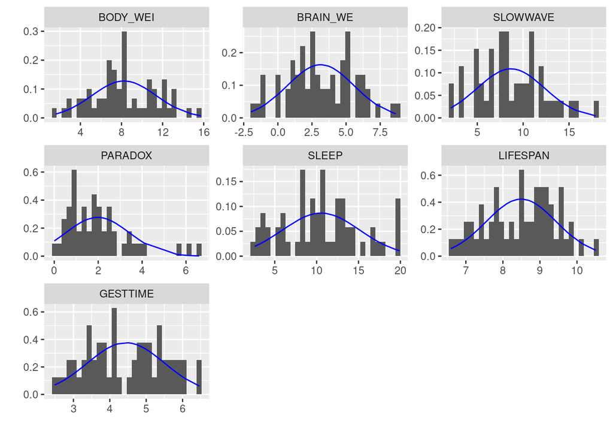

```r
dfMelt <- dfNew %>%
  dplyr::select(-PRED_IND, -EXP_IND, -DANG_IND) %>%
  as.data.frame(dfNew) %>%
  melt(id.vars = "NAME")

ggplot(dfMelt, aes(x = value)) +
        geom_histogram(aes(y = ..density..)) +
        facet_wrap(~variable, scales = "free") +
        labs(x = "", y = "") +
        geom_line(aes(y = dnorm(value,
                      mean = tapply(value, variable, mean, na.rm = TRUE)[PANEL],
                      sd = tapply(value, variable, sd, na.rm = TRUE)[PANEL]
                      )), color = "blue")
```

Изобразим выборочную функцию распредления признаков на фоне функции распределения нормального распределения.

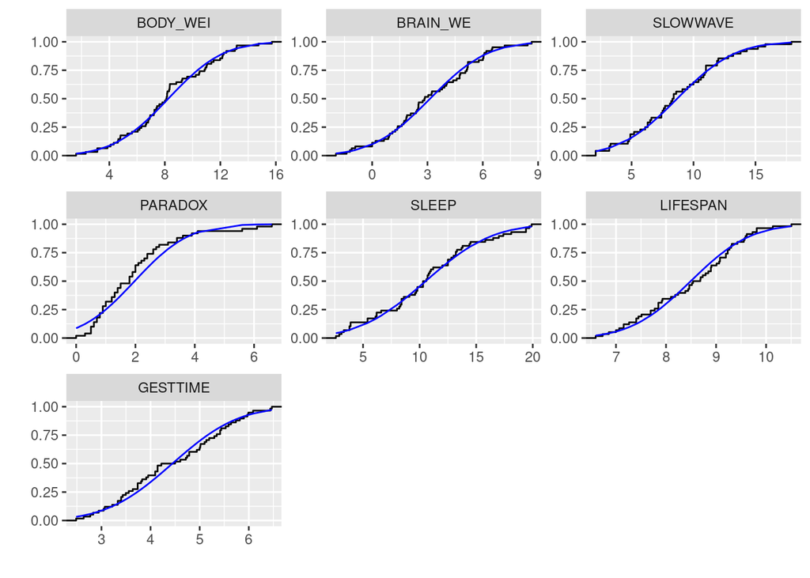

```r
ggplot(dfMelt, aes(x = value)) +
        stat_ecdf() +
        facet_wrap(~variable, scales = "free") +
        labs(x = "", y = "") +
        geom_line(aes(y = pnorm(value,
                      mean = tapply(value, variable, mean, na.rm = TRUE)[PANEL],
                      sd = tapply(value, variable, sd, na.rm = TRUE)[PANEL]
                      )), color = "blue")
```

Можно заметить, что имеет место нормальность распределения признаков. Давайте еще нарисуем PP-plot и QQ-plot.

```r
library(qqplotr)
```

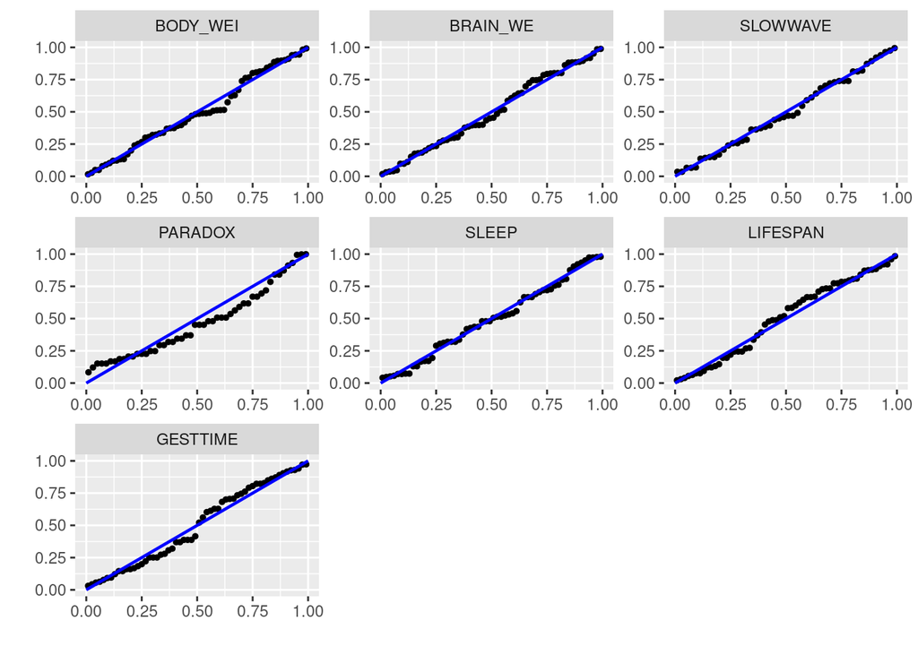

```r
ggplot(dfMelt, aes(sample = value)) +
        stat_pp_point(size = 1) +
        facet_wrap(~variable, scales = "free") +
        labs(x = "", y = "") +
        stat_pp_line(color = "blue")
```

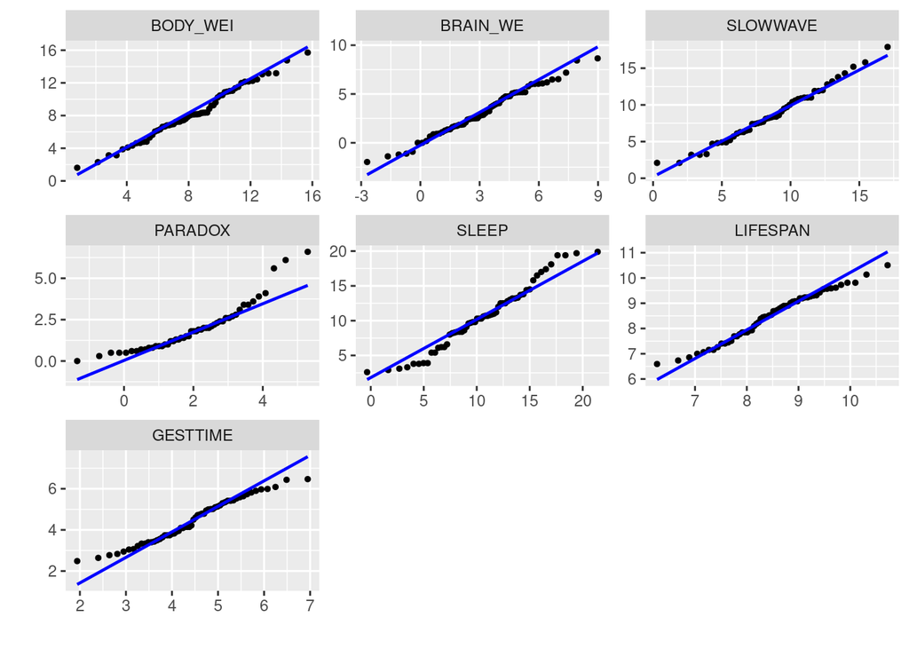

```r
ggplot(dfMelt, aes(sample = value)) +
        stat_qq_point(size = 1) +
        facet_wrap(~variable, scales = "free") +
        labs(x = "", y = "") +
        stat_qq_line(color = "blue")
```

Проверим это с помощью признаков.

Используем критерий Колмогорова-Смирнова, так как распределения абсолютно непрерывны.

```r
ks.test(dfNew$BODY_WEI, "pnorm", mean = mean(dfNew$BODY_WEI, na.rm=TRUE), sd = sd(dfNew$BODY_WEI, na.rm=TRUE))
```

```
##
##  One-sample Kolmogorov-Smirnov test
##
## data:  dfNew$BODY_WEI
## D = 0.11393, p-value = 0.3968
## alternative hypothesis: two-sided
```

```r
ks.test(dfNew$BRAIN_WE, "pnorm", mean = mean(dfNew$BRAIN_WE, na.rm=TRUE), sd = sd(dfNew$BRAIN_WE, na.rm=TRUE))
```

```
##
##  One-sample Kolmogorov-Smirnov test
##
## data:  dfNew$BRAIN_WE
## D = 0.066897, p-value = 0.9442
## alternative hypothesis: two-sided
```

```r
ks.test(dfNew$SLOWWAVE, "pnorm", mean = mean(dfNew$SLOWWAVE, na.rm=TRUE), sd = sd(dfNew$SLOWWAVE, na.rm=TRUE))
```

```
##
##  One-sample Kolmogorov-Smirnov test
##
## data:  dfNew$SLOWWAVE
## D = 0.071335, p-value = 0.9675
## alternative hypothesis: two-sided
```

```r
ks.test(dfNew$PARADOX, "pnorm", mean = mean(dfNew$PARADOX, na.rm=TRUE), sd = sd(dfNew$PARADOX, na.rm=TRUE))
```

```
##
##  One-sample Kolmogorov-Smirnov test
##
## data:  dfNew$PARADOX
## D = 0.13226, p-value = 0.346
## alternative hypothesis: two-sided
```

```r
ks.test(dfNew$SLEEP, "pnorm", mean = mean(dfNew$SLEEP, na.rm=TRUE), sd = sd(dfNew$SLEEP, na.rm=TRUE))
```

```
##
##  One-sample Kolmogorov-Smirnov test
##
## data:  dfNew$SLEEP
## D = 0.063108, p-value = 0.975
## alternative hypothesis: two-sided
```

```r
ks.test(dfNew$LIFESPAN, "pnorm", mean = mean(dfNew$LIFESPAN, na.rm=TRUE), sd = sd(dfNew$LIFESPAN, na.rm=TRUE))
```

```
##
##  One-sample Kolmogorov-Smirnov test
##
## data:  dfNew$LIFESPAN
## D = 0.080606, p-value = 0.8454
## alternative hypothesis: two-sided
```

```r
ks.test(dfNew$GESTTIME, "pnorm", mean = mean(dfNew$GESTTIME, na.rm=TRUE), sd = sd(dfNew$GESTTIME, na.rm=TRUE))
```

```
##
##  One-sample Kolmogorov-Smirnov test
##
## data:  dfNew$GESTTIME
## D = 0.094533, p-value = 0.6778
## alternative hypothesis: two-sided
```

### Индивидуальное задание 1.

Опишем разницу между животными по степени опасности места, где они спят.

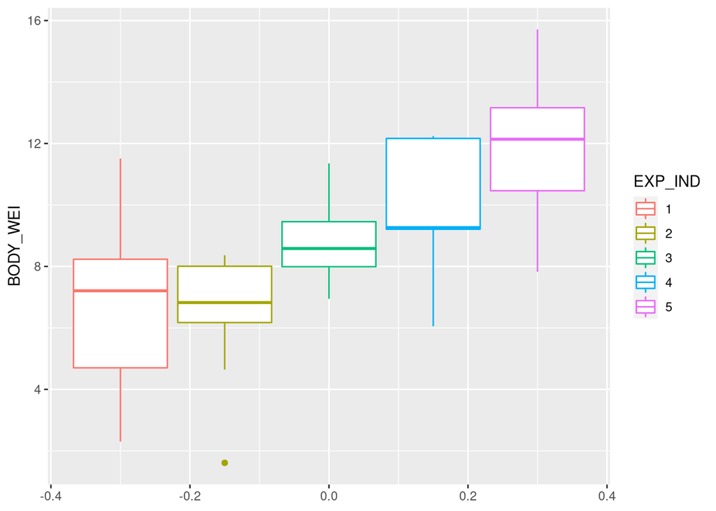

```r
dfNew %>% ggplot(aes(y=BODY_WEI, colour=EXP_IND)) + geom_boxplot()
```

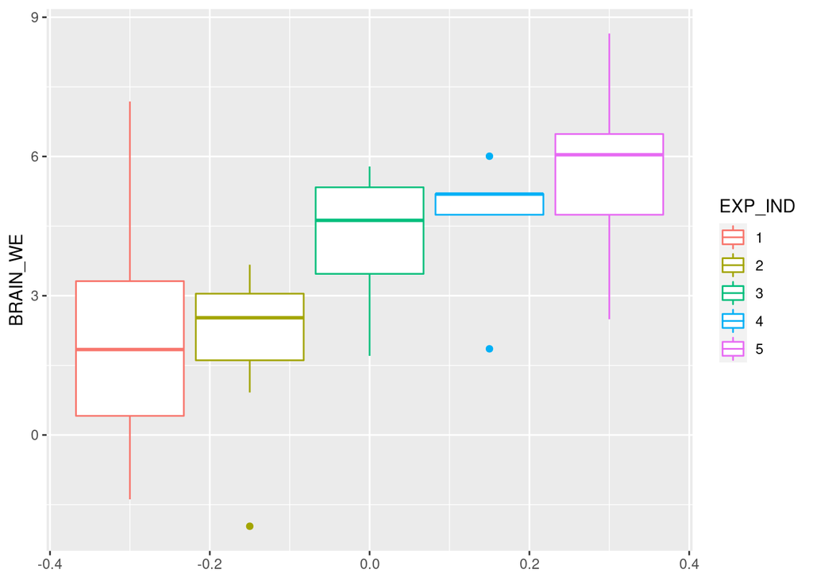

```r
dfNew %>% ggplot(aes(y=BRAIN_WE, colour=EXP_IND)) + geom_boxplot()
```

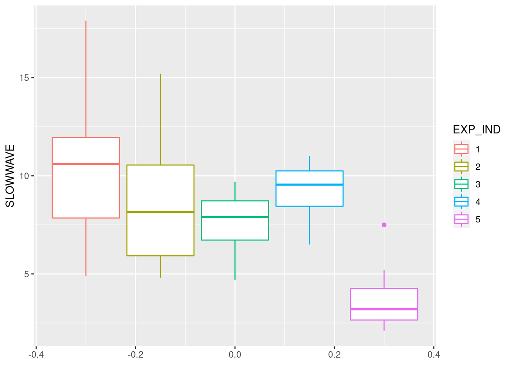

```r
dfNew %>% ggplot(aes(y=SLOWWAVE, colour=EXP_IND)) + geom_boxplot()
```

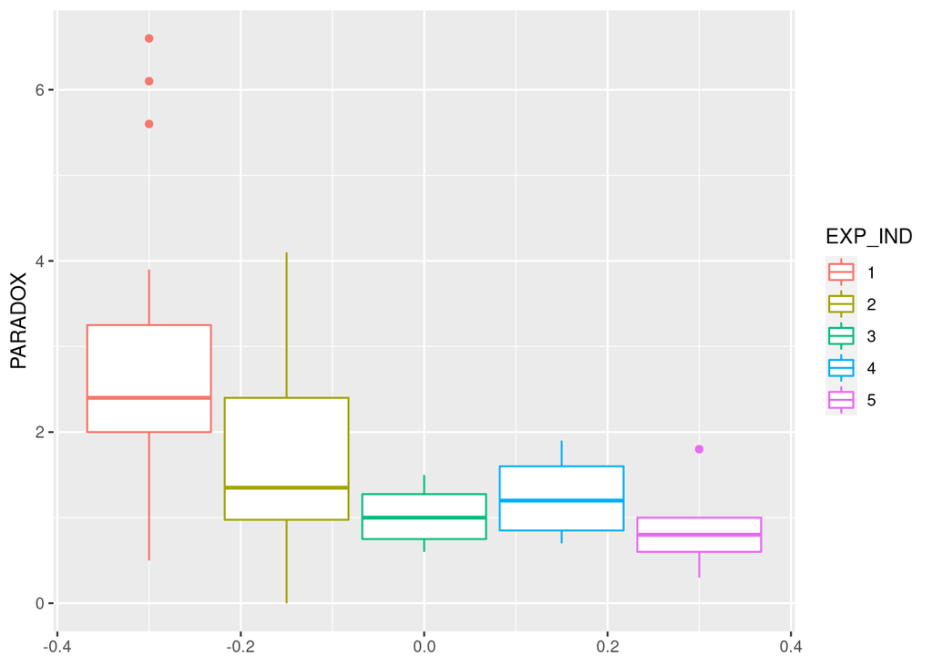

```r
dfNew %>% ggplot(aes(y=PARADOX, colour=EXP_IND)) + geom_boxplot()
```

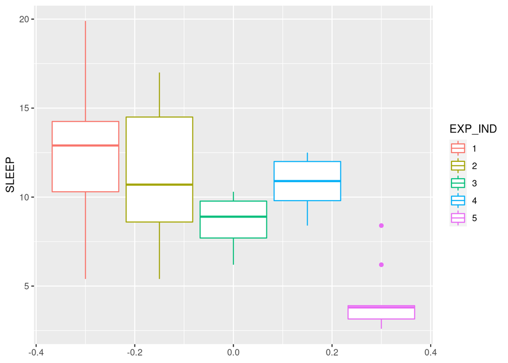

```r
dfNew %>% ggplot(aes(y=SLEEP, colour=EXP_IND)) + geom_boxplot()
```

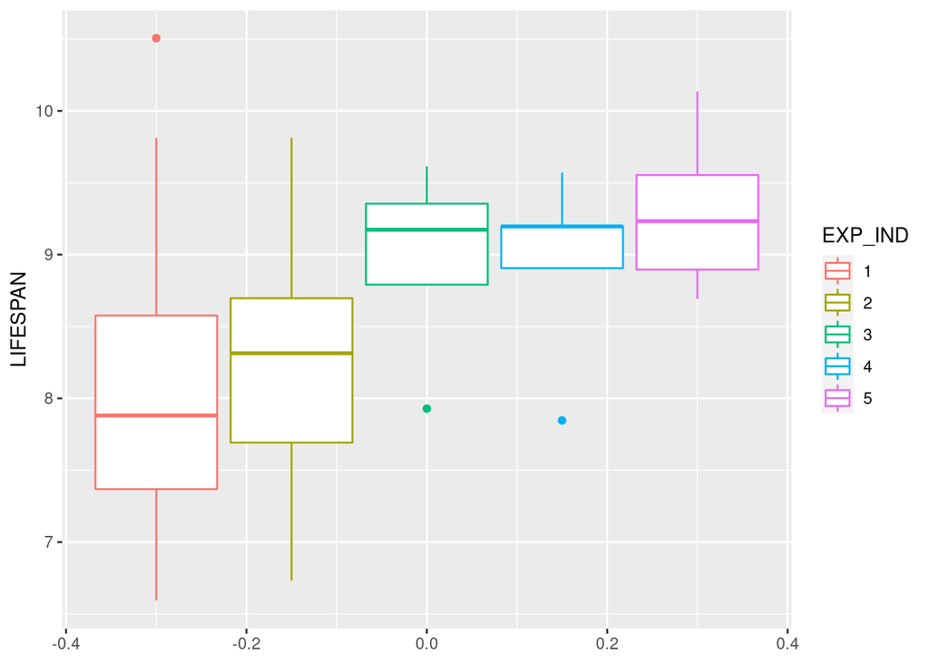

```r
dfNew %>% ggplot(aes(y=LIFESPAN, colour=EXP_IND)) + geom_boxplot()
```

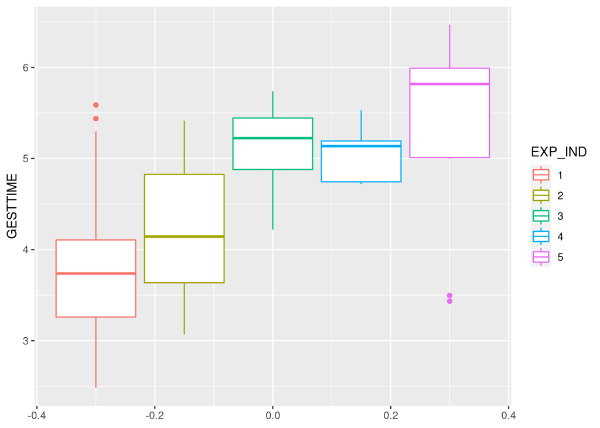

```r
dfNew %>% ggplot(aes(y=GESTTIME, colour=EXP_IND)) + geom_boxplot()
```

Можно заметить, что животные живущие в более защищенных местах 1,2) имеют меньший вес тела и мозга; 3,4,5) чаще дольше спят в общем и в разных фазах сна по отдельности; 6,7) имеют менее длительные продолжительность жизни и период вынашивания потомства. Проверим это с помощью критериев.

Используем Welch-test, так как выборки независимые и нам не известны дисперсии.

```r
dfNew1 <- dplyr::filter(dfNew, EXP_IND == 1)
dfNew2 <- dplyr::filter(dfNew, EXP_IND == 2)
dfNew3 <- dplyr::filter(dfNew, EXP_IND == 3)
dfNew4 <- dplyr::filter(dfNew, EXP_IND == 4)
dfNew5 <- dplyr::filter(dfNew, EXP_IND == 5)

length(dfNew1$NAME)
```

```
## [1] 27
```

```r
length(dfNew2$NAME)
```

```
## [1] 13
```

```r
length(dfNew3$NAME)
```

```
## [1] 4
```

```r
length(dfNew4$NAME)
```

```
## [1] 5
```

```r
length(dfNew5$NAME)
```

```
## [1] 13
```

```r
t.test(dfNew1$BODY_WEI, dfNew2$BODY_WEI, alternative="less")
```

```
##
##  Welch Two Sample t-test
##
## data:  dfNew1$BODY_WEI and dfNew2$BODY_WEI
## t = 0.50334, df = 32.648, p-value = 0.6909
## alternative hypothesis: true difference in means is less than 0
## 95 percent confidence interval:
##      -Inf 1.592087
## sample estimates:
## mean of x mean of y
##  6.902725  6.537842
```

```r
t.test(dfNew1$BODY_WEI, dfNew3$BODY_WEI, alternative="less")
```

```
##
##  Welch Two Sample t-test
##
## data:  dfNew1$BODY_WEI and dfNew3$BODY_WEI
## t = -1.8673, df = 5.0821, p-value = 0.05995
## alternative hypothesis: true difference in means is less than 0
## 95 percent confidence interval:
##       -Inf 0.1478129
## sample estimates:
## mean of x mean of y
##  6.902725  8.865629
```

```r
t.test(dfNew1$BODY_WEI, dfNew4$BODY_WEI, alternative="less")
```

```
##
##  Welch Two Sample t-test
##
## data:  dfNew1$BODY_WEI and dfNew4$BODY_WEI
## t = -2.2998, df = 5.7131, p-value = 0.03164
## alternative hypothesis: true difference in means is less than 0
## 95 percent confidence interval:
##        -Inf -0.4250773
## sample estimates:
## mean of x mean of y
##  6.902725  9.786407
```

```r
t.test(dfNew1$BODY_WEI, dfNew5$BODY_WEI, alternative="less")
```

```
##
##  Welch Two Sample t-test
##
## data:  dfNew1$BODY_WEI and dfNew5$BODY_WEI
## t = -6.4484, df = 28.943, p-value = 2.368e-07
## alternative hypothesis: true difference in means is less than 0
## 95 percent confidence interval:
##       -Inf -3.722811
## sample estimates:
## mean of x mean of y
##  6.902725 11.957552
```

```r
t.test(dfNew2$BODY_WEI, dfNew3$BODY_WEI, alternative="less")
```

```
##
##  Welch Two Sample t-test
##
## data:  dfNew2$BODY_WEI and dfNew3$BODY_WEI
## t = -2.2102, df = 5.0528, p-value = 0.03876
## alternative hypothesis: true difference in means is less than 0
## 95 percent confidence interval:
##        -Inf -0.2104036
## sample estimates:
## mean of x mean of y
##  6.537842  8.865629
```

```r
t.test(dfNew2$BODY_WEI, dfNew4$BODY_WEI, alternative="less")
```

```
##
##  Welch Two Sample t-test
##
## data:  dfNew2$BODY_WEI and dfNew4$BODY_WEI
## t = -2.5874, df = 5.7011, p-value = 0.02167
## alternative hypothesis: true difference in means is less than 0
## 95 percent confidence interval:
##        -Inf -0.7856934
## sample estimates:
## mean of x mean of y
##  6.537842  9.786407
```

```r
t.test(dfNew2$BODY_WEI, dfNew5$BODY_WEI, alternative="less")
```

```
##
##  Welch Two Sample t-test
##
## data:  dfNew2$BODY_WEI and dfNew5$BODY_WEI
## t = -6.8903, df = 23.514, p-value = 2.229e-07
## alternative hypothesis: true difference in means is less than 0
## 95 percent confidence interval:
##       -Inf -4.072869
## sample estimates:
## mean of x mean of y
##  6.537842 11.957552
```

```r
t.test(dfNew3$BODY_WEI, dfNew4$BODY_WEI, alternative="less")
```

```
##
##  Welch Two Sample t-test
##
## data:  dfNew3$BODY_WEI and dfNew4$BODY_WEI
## t = -0.6271, df = 6.9613, p-value = 0.2753
## alternative hypothesis: true difference in means is less than 0
## 95 percent confidence interval:
##      -Inf 1.863405
## sample estimates:
## mean of x mean of y
##  8.865629  9.786407
```

```r
t.test(dfNew3$BODY_WEI, dfNew5$BODY_WEI, alternative="less")
```

```
##
##  Welch Two Sample t-test
##
## data:  dfNew3$BODY_WEI and dfNew5$BODY_WEI
## t = -2.8246, df = 5.7869, p-value = 0.01569
## alternative hypothesis: true difference in means is less than 0
## 95 percent confidence interval:
##        -Inf -0.9507331
## sample estimates:
## mean of x mean of y
##  8.865629 11.957552
```

```r
t.test(dfNew4$BODY_WEI, dfNew5$BODY_WEI, alternative="less")
```

```
##
##  Welch Two Sample t-test
##
## data:  dfNew4$BODY_WEI and dfNew5$BODY_WEI
## t = -1.6824, df = 6.2966, p-value = 0.07057
## alternative hypothesis: true difference in means is less than 0
## 95 percent confidence interval:
##       -Inf 0.3155406
## sample estimates:
## mean of x mean of y
##  9.786407 11.957552
```

```r
t.test(dfNew1$BRAIN_WE, dfNew2$BRAIN_WE, alternative="less")
```

```
##
##  Welch Two Sample t-test
##
## data:  dfNew1$BRAIN_WE and dfNew2$BRAIN_WE
## t = -0.23305, df = 34.091, p-value = 0.4086
## alternative hypothesis: true difference in means is less than 0
## 95 percent confidence interval:
##      -Inf 0.869673
## sample estimates:
## mean of x mean of y
##  1.966034  2.105068
```

```r
t.test(dfNew1$BRAIN_WE, dfNew3$BRAIN_WE, alternative="less")
```

```
##
##  Welch Two Sample t-test
##
## data:  dfNew1$BRAIN_WE and dfNew3$BRAIN_WE
## t = -2.2201, df = 4.5203, p-value = 0.04142
## alternative hypothesis: true difference in means is less than 0
## 95 percent confidence interval:
##        -Inf -0.1566828
## sample estimates:
## mean of x mean of y
##  1.966034  4.184101
```

```r
t.test(dfNew1$BRAIN_WE, dfNew4$BRAIN_WE, alternative="less")
```

```
##
##  Welch Two Sample t-test
##
## data:  dfNew1$BRAIN_WE and dfNew4$BRAIN_WE
## t = -3.1486, df = 7.3199, p-value = 0.007635
## alternative hypothesis: true difference in means is less than 0
## 95 percent confidence interval:
##       -Inf -1.058668
## sample estimates:
## mean of x mean of y
##  1.966034  4.598143
```

```r
t.test(dfNew1$BRAIN_WE, dfNew5$BRAIN_WE, alternative="less")
```

```
##
##  Welch Two Sample t-test
##
## data:  dfNew1$BRAIN_WE and dfNew5$BRAIN_WE
## t = -5.9243, df = 31.034, p-value = 7.58e-07
## alternative hypothesis: true difference in means is less than 0
## 95 percent confidence interval:
##       -Inf -2.688208
## sample estimates:
## mean of x mean of y
##  1.966034  5.732027
```

```r
t.test(dfNew2$BRAIN_WE, dfNew3$BRAIN_WE, alternative="less")
```

```
##
##  Welch Two Sample t-test
##
## data:  dfNew2$BRAIN_WE and dfNew3$BRAIN_WE
## t = -2.1011, df = 4.3292, p-value = 0.04912
## alternative hypothesis: true difference in means is less than 0
## 95 percent confidence interval:
##         -Inf -0.01484397
## sample estimates:
## mean of x mean of y
##  2.105068  4.184101
```

```r
t.test(dfNew2$BRAIN_WE, dfNew4$BRAIN_WE, alternative="less")
```

```
##
##  Welch Two Sample t-test
##
## data:  dfNew2$BRAIN_WE and dfNew4$BRAIN_WE
## t = -3.0239, df = 6.8222, p-value = 0.009944
## alternative hypothesis: true difference in means is less than 0
## 95 percent confidence interval:
##        -Inf -0.9249095
## sample estimates:
## mean of x mean of y
##  2.105068  4.598143
```

```r
t.test(dfNew2$BRAIN_WE, dfNew5$BRAIN_WE, alternative="less")
```

```
##
##  Welch Two Sample t-test
##
## data:  dfNew2$BRAIN_WE and dfNew5$BRAIN_WE
## t = -5.8453, df = 23.63, p-value = 2.65e-06
## alternative hypothesis: true difference in means is less than 0
## 95 percent confidence interval:
##       -Inf -2.564697
## sample estimates:
## mean of x mean of y
##  2.105068  5.732027
```

```r
t.test(dfNew3$BRAIN_WE, dfNew4$BRAIN_WE, alternative="less")
```

```
##
##  Welch Two Sample t-test
##
## data:  dfNew3$BRAIN_WE and dfNew4$BRAIN_WE
## t = -0.3601, df = 6.1446, p-value = 0.3654
## alternative hypothesis: true difference in means is less than 0
## 95 percent confidence interval:
##      -Inf 1.810824
## sample estimates:
## mean of x mean of y
##  4.184101  4.598143
```

```r
t.test(dfNew3$BRAIN_WE, dfNew5$BRAIN_WE, alternative="less")
```

```
##
##  Welch Two Sample t-test
##
## data:  dfNew3$BRAIN_WE and dfNew5$BRAIN_WE
## t = -1.5272, df = 4.7328, p-value = 0.09524
## alternative hypothesis: true difference in means is less than 0
## 95 percent confidence interval:
##       -Inf 0.5201738
## sample estimates:
## mean of x mean of y
##  4.184101  5.732027
```

```r
t.test(dfNew4$BRAIN_WE, dfNew5$BRAIN_WE, alternative="less")
```

```
##
##  Welch Two Sample t-test
##
## data:  dfNew4$BRAIN_WE and dfNew5$BRAIN_WE
## t = -1.329, df = 7.649, p-value = 0.1111
## alternative hypothesis: true difference in means is less than 0
## 95 percent confidence interval:
##       -Inf 0.4621503
## sample estimates:
## mean of x mean of y
##  4.598143  5.732027
```

Если не учитывать животных, близких друг другу по значению EXP_IND, то потчти все гипотезы о равенстве мат. ожиданий отверглись в пользу того, что животное, которое спит в более защищенном месте имеет меньший вес мозга, с уровнем значимости 0.05.

```r
t.test(dfNew1$SLOWWAVE, dfNew2$SLOWWAVE, alternative="greater")
```

```
##
##  Welch Two Sample t-test
##
## data:  dfNew1$SLOWWAVE and dfNew2$SLOWWAVE
## t = 1.174, df = 16.295, p-value = 0.1286
## alternative hypothesis: true difference in means is greater than 0
## 95 percent confidence interval:
##  -0.7486663        Inf
## sample estimates:
## mean of x mean of y
##  10.25217   8.71000
```

```r
t.test(dfNew1$SLOWWAVE, dfNew3$SLOWWAVE, alternative="greater")
```

```
##
##  Welch Two Sample t-test
##
## data:  dfNew1$SLOWWAVE and dfNew3$SLOWWAVE
## t = 2.1331, df = 5.9644, p-value = 0.03858
## alternative hypothesis: true difference in means is greater than 0
## 95 percent confidence interval:
##  0.2379708       Inf
## sample estimates:
## mean of x mean of y
##  10.25217   7.55000
```

```r
t.test(dfNew1$SLOWWAVE, dfNew4$SLOWWAVE, alternative="greater")
```

```
##
##  Welch Two Sample t-test
##
## data:  dfNew1$SLOWWAVE and dfNew4$SLOWWAVE
## t = 0.92774, df = 6.6552, p-value = 0.193
## alternative hypothesis: true difference in means is greater than 0
## 95 percent confidence interval:
##  -1.166283       Inf
## sample estimates:
## mean of x mean of y
##  10.25217   9.15000
```

```r
t.test(dfNew1$SLOWWAVE, dfNew5$SLOWWAVE, alternative="greater")
```

```
##
##  Welch Two Sample t-test
##
## data:  dfNew1$SLOWWAVE and dfNew5$SLOWWAVE
## t = 6.4079, df = 17.753, p-value = 2.64e-06
## alternative hypothesis: true difference in means is greater than 0
## 95 percent confidence interval:
##  4.704798      Inf
## sample estimates:
## mean of x mean of y
##  10.25217   3.80000
```

```r
t.test(dfNew2$SLOWWAVE, dfNew3$SLOWWAVE, alternative="greater")
```

```
##
##  Welch Two Sample t-test
##
## data:  dfNew2$SLOWWAVE and dfNew3$SLOWWAVE
## t = 0.75364, df = 9.4577, p-value = 0.2347
## alternative hypothesis: true difference in means is greater than 0
## 95 percent confidence interval:
##  -1.646071       Inf
## sample estimates:
## mean of x mean of y
##      8.71      7.55
```

```r
t.test(dfNew2$SLOWWAVE, dfNew4$SLOWWAVE, alternative="greater")
```

```
##
##  Welch Two Sample t-test
##
## data:  dfNew2$SLOWWAVE and dfNew4$SLOWWAVE
## t = -0.29829, df = 10.269, p-value = 0.6143
## alternative hypothesis: true difference in means is greater than 0
## 95 percent confidence interval:
##  -3.106424       Inf
## sample estimates:
## mean of x mean of y
##      8.71      9.15
```

```r
t.test(dfNew2$SLOWWAVE, dfNew5$SLOWWAVE, alternative="greater")
```

```
##
##  Welch Two Sample t-test
##
## data:  dfNew2$SLOWWAVE and dfNew5$SLOWWAVE
## t = 3.6819, df = 14.399, p-value = 0.00118
## alternative hypothesis: true difference in means is greater than 0
## 95 percent confidence interval:
##  2.565817      Inf
## sample estimates:
## mean of x mean of y
##      8.71      3.80
```

```r
t.test(dfNew3$SLOWWAVE, dfNew4$SLOWWAVE, alternative="greater")
```

```
##
##  Welch Two Sample t-test
##
## data:  dfNew3$SLOWWAVE and dfNew4$SLOWWAVE
## t = -1.1161, df = 5.9474, p-value = 0.8463
## alternative hypothesis: true difference in means is greater than 0
## 95 percent confidence interval:
##  -4.390023       Inf
## sample estimates:
## mean of x mean of y
##      7.55      9.15
```

```r
t.test(dfNew3$SLOWWAVE, dfNew5$SLOWWAVE, alternative="greater")
```

```
##
##  Welch Two Sample t-test
##
## data:  dfNew3$SLOWWAVE and dfNew5$SLOWWAVE
## t = 2.9128, df = 5.8621, p-value = 0.01381
## alternative hypothesis: true difference in means is greater than 0
## 95 percent confidence interval:
##  1.237692      Inf
## sample estimates:
## mean of x mean of y
##      7.55      3.80
```

```r
t.test(dfNew4$SLOWWAVE, dfNew5$SLOWWAVE, alternative="greater")
```

```
##
##  Welch Two Sample t-test
##
## data:  dfNew4$SLOWWAVE and dfNew5$SLOWWAVE
## t = 4.4214, df = 6.3761, p-value = 0.001928
## alternative hypothesis: true difference in means is greater than 0
## 95 percent confidence interval:
##  3.023302      Inf
## sample estimates:
## mean of x mean of y
##      9.15      3.80
```

Тесты подтверждают результаты, наблюдаемые на box-plot-ах.

```r
t.test(dfNew1$PARADOX, dfNew2$PARADOX, alternative="greater")
```

```
##
##  Welch Two Sample t-test
##
## data:  dfNew1$PARADOX and dfNew2$PARADOX
## t = 2.0392, df = 19.535, p-value = 0.02759
## alternative hypothesis: true difference in means is greater than 0
## 95 percent confidence interval:
##  0.1631119       Inf
## sample estimates:
## mean of x mean of y
##  2.804348  1.740000
```

```r
t.test(dfNew1$PARADOX, dfNew3$PARADOX, alternative="greater")
```

```
##
##  Welch Two Sample t-test
##
## data:  dfNew1$PARADOX and dfNew3$PARADOX
## t = 4.7688, df = 19.539, p-value = 6.216e-05
## alternative hypothesis: true difference in means is greater than 0
## 95 percent confidence interval:
##  1.135078      Inf
## sample estimates:
## mean of x mean of y
##  2.804348  1.025000
```

```r
t.test(dfNew1$PARADOX, dfNew4$PARADOX, alternative="greater")
```

```
##
##  Welch Two Sample t-test
##
## data:  dfNew1$PARADOX and dfNew4$PARADOX
## t = 3.7217, df = 12.899, p-value = 0.001297
## alternative hypothesis: true difference in means is greater than 0
## 95 percent confidence interval:
##  0.8142787       Inf
## sample estimates:
## mean of x mean of y
##  2.804348  1.250000
```

```r
t.test(dfNew1$PARADOX, dfNew5$PARADOX, alternative="greater")
```

```
##
##  Welch Two Sample t-test
##
## data:  dfNew1$PARADOX and dfNew5$PARADOX
## t = 5.6838, df = 28.653, p-value = 1.984e-06
## alternative hypothesis: true difference in means is greater than 0
## 95 percent confidence interval:
##  1.373767      Inf
## sample estimates:
## mean of x mean of y
## 2.8043478 0.8444444
```

```r
t.test(dfNew2$PARADOX, dfNew3$PARADOX, alternative="greater")
```

```
##
##  Welch Two Sample t-test
##
## data:  dfNew2$PARADOX and dfNew3$PARADOX
## t = 1.544, df = 11.77, p-value = 0.07452
## alternative hypothesis: true difference in means is greater than 0
## 95 percent confidence interval:
##  -0.1116968        Inf
## sample estimates:
## mean of x mean of y
##     1.740     1.025
```

```r
t.test(dfNew2$PARADOX, dfNew4$PARADOX, alternative="greater")
```

```
##
##  Welch Two Sample t-test
##
## data:  dfNew2$PARADOX and dfNew4$PARADOX
## t = 0.98068, df = 11.818, p-value = 0.1732
## alternative hypothesis: true difference in means is greater than 0
## 95 percent confidence interval:
##  -0.4016744        Inf
## sample estimates:
## mean of x mean of y
##      1.74      1.25
```

```r
t.test(dfNew2$PARADOX, dfNew5$PARADOX, alternative="greater")
```

```
##
##  Welch Two Sample t-test
##
## data:  dfNew2$PARADOX and dfNew5$PARADOX
## t = 2.0326, df = 11.056, p-value = 0.03341
## alternative hypothesis: true difference in means is greater than 0
## 95 percent confidence interval:
##  0.1046509       Inf
## sample estimates:
## mean of x mean of y
## 1.7400000 0.8444444
```

```r
t.test(dfNew3$PARADOX, dfNew4$PARADOX, alternative="greater")
```

```
##
##  Welch Two Sample t-test
##
## data:  dfNew3$PARADOX and dfNew4$PARADOX
## t = -0.65932, df = 5.4975, p-value = 0.7318
## alternative hypothesis: true difference in means is greater than 0
## 95 percent confidence interval:
##  -0.8991439        Inf
## sample estimates:
## mean of x mean of y
##     1.025     1.250
```

```r
t.test(dfNew3$PARADOX, dfNew5$PARADOX, alternative="greater")
```

```
##
##  Welch Two Sample t-test
##
## data:  dfNew3$PARADOX and dfNew5$PARADOX
## t = 0.73145, df = 6.1708, p-value = 0.2457
## alternative hypothesis: true difference in means is greater than 0
## 95 percent confidence interval:
##  -0.2967456        Inf
## sample estimates:
## mean of x mean of y
## 1.0250000 0.8444444
```

```r
t.test(dfNew4$PARADOX, dfNew5$PARADOX, alternative="greater")
```

```
##
##  Welch Two Sample t-test
##
## data:  dfNew4$PARADOX and dfNew5$PARADOX
## t = 1.308, df = 4.6957, p-value = 0.1256
## alternative hypothesis: true difference in means is greater than 0
## 95 percent confidence interval:
##  -0.2283018        Inf
## sample estimates:
## mean of x mean of y
## 1.2500000 0.8444444
```

Тесты подтверждают результаты, наблюдаемые на box-plot-ах.

```r
t.test(dfNew1$SLEEP, dfNew2$SLEEP, alternative="greater")
```

```
##
##  Welch Two Sample t-test
##
## data:  dfNew1$SLEEP and dfNew2$SLEEP
## t = 1.3578, df = 24.312, p-value = 0.0935
## alternative hypothesis: true difference in means is greater than 0
## 95 percent confidence interval:
##  -0.47491      Inf
## sample estimates:
## mean of x mean of y
##  12.94615  11.11538
```

```r
t.test(dfNew1$SLEEP, dfNew3$SLEEP, alternative="greater")
```

```
##
##  Welch Two Sample t-test
##
## data:  dfNew1$SLEEP and dfNew3$SLEEP
## t = 3.6542, df = 8.6128, p-value = 0.002845
## alternative hypothesis: true difference in means is greater than 0
## 95 percent confidence interval:
##  2.167127      Inf
## sample estimates:
## mean of x mean of y
##  12.94615   8.57500
```

```r
t.test(dfNew1$SLEEP, dfNew4$SLEEP, alternative="greater")
```

```
##
##  Welch Two Sample t-test
##
## data:  dfNew1$SLEEP and dfNew4$SLEEP
## t = 2.0607, df = 14.864, p-value = 0.02864
## alternative hypothesis: true difference in means is greater than 0
## 95 percent confidence interval:
##  0.3312501       Inf
## sample estimates:
## mean of x mean of y
##  12.94615  10.72000
```

```r
t.test(dfNew1$SLEEP, dfNew5$SLEEP, alternative="greater")
```

```
##
##  Welch Two Sample t-test
##
## data:  dfNew1$SLEEP and dfNew5$SLEEP
## t = 9.0835, df = 33.045, p-value = 8.383e-11
## alternative hypothesis: true difference in means is greater than 0
## 95 percent confidence interval:
##  7.124839      Inf
## sample estimates:
## mean of x mean of y
##  12.94615   4.19000
```

```r
t.test(dfNew2$SLEEP, dfNew3$SLEEP, alternative="greater")
```

```
##
##  Welch Two Sample t-test
##
## data:  dfNew2$SLEEP and dfNew3$SLEEP
## t = 1.7866, df = 11.898, p-value = 0.04974
## alternative hypothesis: true difference in means is greater than 0
## 95 percent confidence interval:
##  0.004361188         Inf
## sample estimates:
## mean of x mean of y
##  11.11538   8.57500
```

```r
t.test(dfNew2$SLEEP, dfNew4$SLEEP, alternative="greater")
```

```
##
##  Welch Two Sample t-test
##
## data:  dfNew2$SLEEP and dfNew4$SLEEP
## t = 0.29821, df = 15.649, p-value = 0.3847
## alternative hypothesis: true difference in means is greater than 0
## 95 percent confidence interval:
##  -1.922573       Inf
## sample estimates:
## mean of x mean of y
##  11.11538  10.72000
```

```r
t.test(dfNew2$SLEEP, dfNew5$SLEEP, alternative="greater")
```

```
##
##  Welch Two Sample t-test
##
## data:  dfNew2$SLEEP and dfNew5$SLEEP
## t = 5.617, df = 17.51, p-value = 1.38e-05
## alternative hypothesis: true difference in means is greater than 0
## 95 percent confidence interval:
##  4.784157      Inf
## sample estimates:
## mean of x mean of y
##  11.11538   4.19000
```

```r
t.test(dfNew3$SLEEP, dfNew4$SLEEP, alternative="greater")
```

```
##
##  Welch Two Sample t-test
##
## data:  dfNew3$SLEEP and dfNew4$SLEEP
## t = -1.8321, df = 6.279, p-value = 0.9428
## alternative hypothesis: true difference in means is greater than 0
## 95 percent confidence interval:
##  -4.402031       Inf
## sample estimates:
## mean of x mean of y
##     8.575    10.720
```

```r
t.test(dfNew3$SLEEP, dfNew5$SLEEP, alternative="greater")
```

```
##
##  Welch Two Sample t-test
##
## data:  dfNew3$SLEEP and dfNew5$SLEEP
## t = 4.1197, df = 5.4918, p-value = 0.003758
## alternative hypothesis: true difference in means is greater than 0
## 95 percent confidence interval:
##  2.281889      Inf
## sample estimates:
## mean of x mean of y
##     8.575     4.190
```

```r
t.test(dfNew4$SLEEP, dfNew5$SLEEP, alternative="greater")
```

```
##
##  Welch Two Sample t-test
##
## data:  dfNew4$SLEEP and dfNew5$SLEEP
## t = 7.0047, df = 8.6183, p-value = 3.9e-05
## alternative hypothesis: true difference in means is greater than 0
## 95 percent confidence interval:
##  4.812458      Inf
## sample estimates:
## mean of x mean of y
##     10.72      4.19
```

Тесты подтверждают результаты, наблюдаемые на box-plot-ах.

```r
t.test(dfNew1$LIFESPAN, dfNew2$LIFESPAN, alternative="less")
```

```
##
##  Welch Two Sample t-test
##
## data:  dfNew1$LIFESPAN and dfNew2$LIFESPAN
## t = -0.56346, df = 22.112, p-value = 0.2894
## alternative hypothesis: true difference in means is less than 0
## 95 percent confidence interval:
##       -Inf 0.3877679
## sample estimates:
## mean of x mean of y
##  8.050645  8.240094
```

```r
t.test(dfNew1$LIFESPAN, dfNew3$LIFESPAN, alternative="less")
```

```
##
##  Welch Two Sample t-test
##
## data:  dfNew1$LIFESPAN and dfNew3$LIFESPAN
## t = -2.2289, df = 4.8856, p-value = 0.03876
## alternative hypothesis: true difference in means is less than 0
## 95 percent confidence interval:
##         -Inf -0.08410067
## sample estimates:
## mean of x mean of y
##  8.050645  8.972350
```

```r
t.test(dfNew1$LIFESPAN, dfNew4$LIFESPAN, alternative="less")
```

```
##
##  Welch Two Sample t-test
##
## data:  dfNew1$LIFESPAN and dfNew4$LIFESPAN
## t = -2.5347, df = 7.9886, p-value = 0.01752
## alternative hypothesis: true difference in means is less than 0
## 95 percent confidence interval:
##      -Inf -0.23771
## sample estimates:
## mean of x mean of y
##  8.050645  8.943480
```

```r
t.test(dfNew1$LIFESPAN, dfNew5$LIFESPAN, alternative="less")
```

```
##
##  Welch Two Sample t-test
##
## data:  dfNew1$LIFESPAN and dfNew5$LIFESPAN
## t = -5.1312, df = 34.408, p-value = 5.631e-06
## alternative hypothesis: true difference in means is less than 0
## 95 percent confidence interval:
##        -Inf -0.7876324
## sample estimates:
## mean of x mean of y
##  8.050645  9.225212
```

```r
t.test(dfNew2$LIFESPAN, dfNew3$LIFESPAN, alternative="less")
```

```
##
##  Welch Two Sample t-test
##
## data:  dfNew2$LIFESPAN and dfNew3$LIFESPAN
## t = -1.603, df = 6.7608, p-value = 0.07724
## alternative hypothesis: true difference in means is less than 0
## 95 percent confidence interval:
##       -Inf 0.1378001
## sample estimates:
## mean of x mean of y
##  8.240094  8.972350
```

```r
t.test(dfNew2$LIFESPAN, dfNew4$LIFESPAN, alternative="less")
```

```
##
##  Welch Two Sample t-test
##
## data:  dfNew2$LIFESPAN and dfNew4$LIFESPAN
## t = -1.7491, df = 10.983, p-value = 0.05407
## alternative hypothesis: true difference in means is less than 0
## 95 percent confidence interval:
##        -Inf 0.01893388
## sample estimates:
## mean of x mean of y
##  8.240094  8.943480
```

```r
t.test(dfNew2$LIFESPAN, dfNew5$LIFESPAN, alternative="less")
```

```
##
##  Welch Two Sample t-test
##
## data:  dfNew2$LIFESPAN and dfNew5$LIFESPAN
## t = -3.2828, df = 15.181, p-value = 0.002483
## alternative hypothesis: true difference in means is less than 0
## 95 percent confidence interval:
##        -Inf -0.4594596
## sample estimates:
## mean of x mean of y
##  8.240094  9.225212
```

```r
t.test(dfNew3$LIFESPAN, dfNew4$LIFESPAN, alternative="less")
```

```
##
##  Welch Two Sample t-test
##
## data:  dfNew3$LIFESPAN and dfNew4$LIFESPAN
## t = 0.061594, df = 6.1962, p-value = 0.5236
## alternative hypothesis: true difference in means is less than 0
## 95 percent confidence interval:
##       -Inf 0.9345074
## sample estimates:
## mean of x mean of y
##   8.97235   8.94348
```

```r
t.test(dfNew3$LIFESPAN, dfNew5$LIFESPAN, alternative="less")
```

```
##
##  Welch Two Sample t-test
##
## data:  dfNew3$LIFESPAN and dfNew5$LIFESPAN
## t = -0.65726, df = 3.687, p-value = 0.2749
## alternative hypothesis: true difference in means is less than 0
## 95 percent confidence interval:
##       -Inf 0.5877215
## sample estimates:
## mean of x mean of y
##  8.972350  9.225212
```

```r
t.test(dfNew4$LIFESPAN, dfNew5$LIFESPAN, alternative="less")
```

```
##
##  Welch Two Sample t-test
##
## data:  dfNew4$LIFESPAN and dfNew5$LIFESPAN
## t = -0.88615, df = 5.4252, p-value = 0.2065
## alternative hypothesis: true difference in means is less than 0
## 95 percent confidence interval:
##       -Inf 0.3479822
## sample estimates:
## mean of x mean of y
##  8.943480  9.225212
```

Тесты подтверждают результаты, наблюдаемые на box-plot-ах.

```r
t.test(dfNew1$GESTTIME, dfNew2$GESTTIME, alternative="less")
```

```
##
##  Welch Two Sample t-test
##
## data:  dfNew1$GESTTIME and dfNew2$GESTTIME
## t = -1.3944, df = 23.27, p-value = 0.08818
## alternative hypothesis: true difference in means is less than 0
## 95 percent confidence interval:
##        -Inf 0.09354619
## sample estimates:
## mean of x mean of y
##  3.801653  4.211072
```

```r
t.test(dfNew1$GESTTIME, dfNew3$GESTTIME, alternative="less")
```

```
##
##  Welch Two Sample t-test
##
## data:  dfNew1$GESTTIME and dfNew3$GESTTIME
## t = -3.5437, df = 5.0035, p-value = 0.008239
## alternative hypothesis: true difference in means is less than 0
## 95 percent confidence interval:
##        -Inf -0.5605157
## sample estimates:
## mean of x mean of y
##  3.801653  5.100763
```

```r
t.test(dfNew1$GESTTIME, dfNew4$GESTTIME, alternative="less")
```

```
##
##  Welch Two Sample t-test
##
## data:  dfNew1$GESTTIME and dfNew4$GESTTIME
## t = -5.4382, df = 16.74, p-value = 2.335e-05
## alternative hypothesis: true difference in means is less than 0
## 95 percent confidence interval:
##        -Inf -0.8584007
## sample estimates:
## mean of x mean of y
##  3.801653  5.064323
```

```r
t.test(dfNew1$GESTTIME, dfNew5$GESTTIME, alternative="less")
```

```
##
##  Welch Two Sample t-test
##
## data:  dfNew1$GESTTIME and dfNew5$GESTTIME
## t = -4.9125, df = 21.914, p-value = 3.29e-05
## alternative hypothesis: true difference in means is less than 0
## 95 percent confidence interval:
##       -Inf -1.042855
## sample estimates:
## mean of x mean of y
##  3.801653  5.405068
```

```r
t.test(dfNew2$GESTTIME, dfNew3$GESTTIME, alternative="less")
```

```
##
##  Welch Two Sample t-test
##
## data:  dfNew2$GESTTIME and dfNew3$GESTTIME
## t = -2.233, df = 6.5519, p-value = 0.03163
## alternative hypothesis: true difference in means is less than 0
## 95 percent confidence interval:
##        -Inf -0.1270123
## sample estimates:
## mean of x mean of y
##  4.211072  5.100763
```

```r
t.test(dfNew2$GESTTIME, dfNew4$GESTTIME, alternative="less")
```

```
##
##  Welch Two Sample t-test
##
## data:  dfNew2$GESTTIME and dfNew4$GESTTIME
## t = -3.0501, df = 14.944, p-value = 0.004065
## alternative hypothesis: true difference in means is less than 0
## 95 percent confidence interval:
##        -Inf -0.3627295
## sample estimates:
## mean of x mean of y
##  4.211072  5.064323
```

```r
t.test(dfNew2$GESTTIME, dfNew5$GESTTIME, alternative="less")
```

```
##
##  Welch Two Sample t-test
##
## data:  dfNew2$GESTTIME and dfNew5$GESTTIME
## t = -3.3004, df = 22.715, p-value = 0.001582
## alternative hypothesis: true difference in means is less than 0
## 95 percent confidence interval:
##        -Inf -0.5736414
## sample estimates:
## mean of x mean of y
##  4.211072  5.405068
```

```r
t.test(dfNew3$GESTTIME, dfNew4$GESTTIME, alternative="less")
```

```
##
##  Welch Two Sample t-test
##
## data:  dfNew3$GESTTIME and dfNew4$GESTTIME
## t = 0.10248, df = 4.3207, p-value = 0.5385
## alternative hypothesis: true difference in means is less than 0
## 95 percent confidence interval:
##       -Inf 0.7786134
## sample estimates:
## mean of x mean of y
##  5.100763  5.064323
```

```r
t.test(dfNew3$GESTTIME, dfNew5$GESTTIME, alternative="less")
```

```
##
##  Welch Two Sample t-test
##
## data:  dfNew3$GESTTIME and dfNew5$GESTTIME
## t = -0.71912, df = 7.9279, p-value = 0.2464
## alternative hypothesis: true difference in means is less than 0
## 95 percent confidence interval:
##       -Inf 0.4835108
## sample estimates:
## mean of x mean of y
##  5.100763  5.405068
```

```r
t.test(dfNew4$GESTTIME, dfNew5$GESTTIME, alternative="less")
```

```
##
##  Welch Two Sample t-test
##
## data:  dfNew4$GESTTIME and dfNew5$GESTTIME
## t = -1.0853, df = 15.976, p-value = 0.147
## alternative hypothesis: true difference in means is less than 0
## 95 percent confidence interval:
##       -Inf 0.2074721
## sample estimates:
## mean of x mean of y
##  5.064323  5.405068
```

Тесты подтверждают результаты, наблюдаемые на box-plot-ах.

## Дальше смотреть не надо.

Посмотрим на корреляции между признаками.

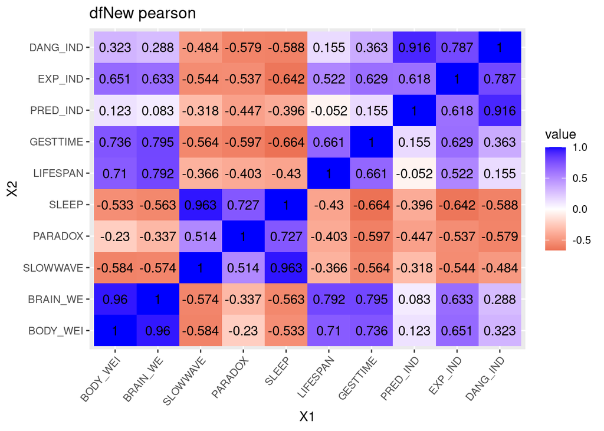

```r
dplyr::select(dfNew, -NAME) %>%
mutate(PRED_IND = as.numeric(PRED_IND), EXP_IND = as.numeric(EXP_IND), DANG_IND = as.numeric(DANG_IND)) %>%
cor(method = "pearson", use = "pairwise.complete.obs") %>%
melt() %>%
ggplot(aes(X1, X2)) +
  geom_raster(aes(fill = value)) +
  geom_text(aes(label = round(value, 3))) +
  scale_fill_gradient2(low=colors()[555], mid=colors()[1], high=colors()[26]) +
  ggtitle("dfNew pearson") +
  theme(axis.text.x = element_text(angle = 50, hjust = 1))
```

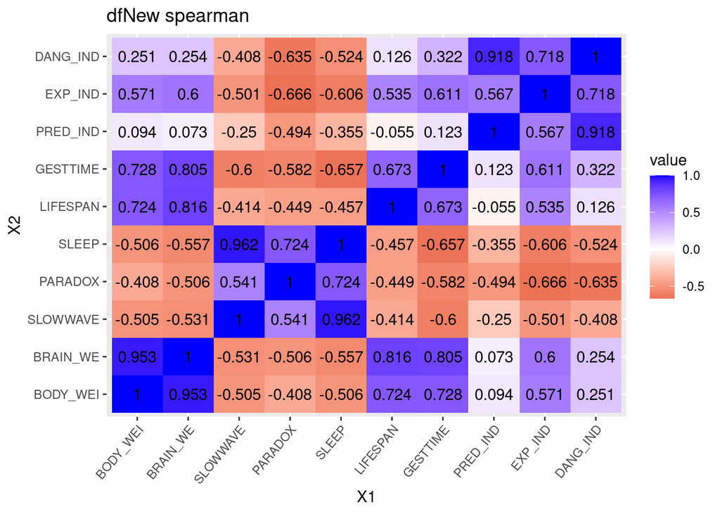

```r
dplyr::select(dfNew, -NAME) %>%
mutate(PRED_IND = as.numeric(PRED_IND), EXP_IND = as.numeric(EXP_IND), DANG_IND = as.numeric(DANG_IND)) %>%
cor(method = "spearman", use = "pairwise.complete.obs") %>%
melt() %>%
ggplot(aes(X1, X2)) +
  geom_raster(aes(fill = value)) +
  geom_text(aes(label = round(value, 3))) +
  scale_fill_gradient2(low=colors()[555], mid=colors()[1], high=colors()[26]) +
  ggtitle("dfNew spearman") +
  theme(axis.text.x = element_text(angle = 50, hjust = 1))
```

В качестве описания зависимостей между критериями выше представленны ggpairs и correlation matrix plot. Также посчитаем интересные частные корреляции.

```r
library(ppcor)
```

Посмотрим на частную корреляцию веса животного и сна за вычетом идексов опасности.

```r
((dplyr::select(dfNew, -NAME, -BRAIN_WE, -LIFESPAN, -GESTTIME, -SLOWWAVE, -PARADOX) %>%
  mutate(PRED_IND = as.numeric(PRED_IND), EXP_IND = as.numeric(EXP_IND), DANG_IND = as.numeric(DANG_IND)) %>%
  drop_na() %>%
  pcor(method = "spearman"))$estimate %>%
as.data.frame())["SLEEP", "BODY_WEI"]
```

```
## [1] -0.2668484
```

```r
((dplyr::select(dfNew, -NAME, -BRAIN_WE, -LIFESPAN, -GESTTIME, -SLEEP, -PARADOX) %>%
  mutate(PRED_IND = as.numeric(PRED_IND), EXP_IND = as.numeric(EXP_IND), DANG_IND = as.numeric(DANG_IND)) %>%
  drop_na() %>%
  pcor(method = "spearman"))$estimate %>%
as.data.frame())["SLOWWAVE", "BODY_WEI"]
```

```
## [1] -0.2870771
```

```r
((dplyr::select(dfNew, -NAME, -BRAIN_WE, -LIFESPAN, -GESTTIME, -SLOWWAVE, -SLEEP) %>%
  mutate(PRED_IND = as.numeric(PRED_IND), EXP_IND = as.numeric(EXP_IND), DANG_IND = as.numeric(DANG_IND)) %>%
  drop_na() %>%
  pcor(method = "spearman"))$estimate %>%
as.data.frame())["PARADOX", "BODY_WEI"]
```

```
## [1] -0.003219317
```

Посмотрим на частые корреляции индексов опасности животного и сна за вычетом веса и связанных с ним критериев.

```r
((dplyr::select(dfNew, -NAME, -EXP_IND, -DANG_IND, -SLOWWAVE, -PARADOX) %>%
  mutate(PRED_IND = as.numeric(PRED_IND)) %>%
  drop_na() %>%
  pcor(method = "spearman"))$estimate %>%
as.data.frame())["SLEEP", "PRED_IND"]
```

```
## [1] -0.4838444
```

```r
((dplyr::select(dfNew, -NAME, -EXP_IND, -DANG_IND, -SLEEP, -PARADOX) %>%
  mutate(PRED_IND = as.numeric(PRED_IND)) %>%
  drop_na() %>%
  pcor(method = "spearman"))$estimate %>%
as.data.frame())["SLOWWAVE", "PRED_IND"]
```

```
## [1] -0.2729752
```

```r
((dplyr::select(dfNew, -NAME, -EXP_IND, -DANG_IND, -SLOWWAVE, -SLEEP) %>%
  mutate(PRED_IND = as.numeric(PRED_IND)) %>%
  drop_na() %>%
  pcor(method = "spearman"))$estimate %>%
as.data.frame())["PARADOX", "PRED_IND"]
```

```
## [1] -0.5605862
```

```r
((dplyr::select(dfNew, -NAME, -PRED_IND, -DANG_IND, -SLOWWAVE, -PARADOX) %>%
  mutate(EXP_IND = as.numeric(EXP_IND)) %>%
  drop_na() %>%
  pcor(method = "spearman"))$estimate %>%
as.data.frame())["SLEEP", "EXP_IND"]
```

```
## [1] -0.4055336
```

```r
((dplyr::select(dfNew, -NAME, -PRED_IND, -DANG_IND, -SLEEP, -PARADOX) %>%
  mutate(EXP_IND = as.numeric(EXP_IND)) %>%
  drop_na() %>%
  pcor(method = "spearman"))$estimate %>%
as.data.frame())["SLOWWAVE", "EXP_IND"]
```

```
## [1] -0.2385904
```

```r
((dplyr::select(dfNew, -NAME, -PRED_IND, -DANG_IND, -SLOWWAVE, -SLEEP) %>%
  mutate(EXP_IND = as.numeric(EXP_IND)) %>%
  drop_na() %>%
  pcor(method = "spearman"))$estimate %>%
as.data.frame())["PARADOX", "EXP_IND"]
```

```
## [1] -0.4508023
```

```r
((dplyr::select(dfNew, -NAME, -PRED_IND, -EXP_IND, -SLOWWAVE, -PARADOX) %>%
  mutate(DANG_IND = as.numeric(DANG_IND)) %>%
  drop_na() %>%
  pcor(method = "spearman"))$estimate %>%
as.data.frame())["SLEEP", "DANG_IND"]
```

```
## [1] -0.5687154
```

```r
((dplyr::select(dfNew, -NAME, -PRED_IND, -EXP_IND, -SLEEP, -PARADOX) %>%
  mutate(DANG_IND = as.numeric(DANG_IND)) %>%
  drop_na() %>%
  pcor(method = "spearman"))$estimate %>%
as.data.frame())["SLOWWAVE", "DANG_IND"]
```

```
## [1] -0.366575
```

```r
((dplyr::select(dfNew, -NAME, -PRED_IND, -EXP_IND, -SLOWWAVE, -SLEEP) %>%
  mutate(DANG_IND = as.numeric(DANG_IND)) %>%
  drop_na() %>%
  pcor(method = "spearman"))$estimate %>%
as.data.frame())["PARADOX", "DANG_IND"]
```

```
## [1] -0.623655
```